# Zadaća 1

Tim:

```
Adnan Elezovic
Haris Halilović
Ibrahim Dedeić
```

Broj indeksa:

[output not shown]

Nastavna grupa:

```
4
```

## Zadatak 1

Prije svega, učitavamo naš dataset.

```r
data<-read.csv("weather_data_train.csv", header=TRUE)
```

Sada ćemo očitati dimenzije seta koristeći funkciju *dim()*.

```r
dim(data)
```

```
## [1] 2000   14
```

Vidimo da naš set sadrži 2000 rekorda (*redova*), a 14 polja (*kolona*).

Dalje, zanimaju nas *tipovi* pojedinačnih atributa unutar seta. Tu informaciju možemo koristeći funkciju *sapply(data, class)*, ali možemo isto tako očitati iste te informacije sa sažetog izvještaja koristeći funkciju *summary(data)*:

```r
summary(data)
```

```
##    Location            MinTemp         MaxTemp         Rainfall
##  Length:2000        Min.   :-3.70   Min.   : 7.30   Min.   :  0.000
##  Class :character   1st Qu.: 8.20   1st Qu.:18.50   1st Qu.:  0.000
##  Mode  :character   Median :12.70   Median :23.80   Median :  0.000
##                     Mean   :13.23   Mean   :24.05   Mean   :  2.482
##                     3rd Qu.:18.40   3rd Qu.:29.50   3rd Qu.:  0.700
##                     Max.   :30.20   Max.   :46.40   Max.   :367.600
##                     NA's   :245     NA's   :210     NA's   :249
##  WindGustDir        WindGustSpeed    RainToday          Humidity9am
##  Length:2000        Min.   :11.00   Length:2000        Min.   :  2.00
##  Class :character   1st Qu.:31.00   Class :character   1st Qu.: 56.00
##  Mode  :character   Median :39.00   Mode  :character   Median : 68.00
##                     Mean   :40.88                      Mean   : 67.03
##                     3rd Qu.:48.00                      3rd Qu.: 81.00
##                     Max.   :98.00                      Max.   :100.00
##                     NA's   :189                        NA's   :265
##     Cloud9am      Pressure9am      WindDir9am         WindDir3pm
##  Min.   :0.000   Min.   : 987.2   Length:2000        Length:2000
##  1st Qu.:1.000   1st Qu.:1012.7   Class :character   Class :character
##  Median :5.000   Median :1017.3   Mode  :character   Mode  :character
##  Mean   :4.347   Mean   :1017.3
##  3rd Qu.:7.000   3rd Qu.:1021.9
##  Max.   :8.000   Max.   :1040.1
##  NA's   :267     NA's   :249
##     Cloud5pm      RainTomorrow
##  Min.   :0.0000   Length:2000
##  1st Qu.:0.2000   Class :character
##  Median :1.0000   Mode  :character
##  Mean   :0.8694
##  3rd Qu.:1.4000
##  Max.   :1.6000
##  NA's   :267
```

Možemo i neke primjer vrijednosti vidjeti koristeći

```r
str(data)
```

```
## 'data.frame':    2000 obs. of  14 variables:
##  $ Location     : chr  "PearceRAAF" "Wollongong" "Moree" "CoffsHarbour" ...
##  $ MinTemp      : num  17.9 15.1 18.5 22.2 17.8 NA 20.9 7.2 5.2 NA ...
##  $ MaxTemp      : num  33.5 20.3 27.9 27.6 26.8 13.2 25.6 19.2 12.4 30.5 ...
##  $ Rainfall     : num  0 2 14 0 0 0.6 0 0 0 0 ...
##  $ WindGustDir  : chr  "ENE" "SSE" "S" "SSW" ...
##  $ WindGustSpeed: int  39 NA 72 46 19 NA 37 28 20 30 ...
##  $ RainToday    : chr  "No" "Yes" "Yes" NA ...
##  $ Humidity9am  : int  30 58 80 82 NA 68 64 99 94 73 ...
##  $ Cloud9am     : int  NA NA 5 7 4 1 6 2 NA 5 ...
##  $ Pressure9am  : num  1016 NA 1004 1011 1021 ...
##  $ WindDir9am   : chr  "NNE" "SSE" "SSW" "SSW" ...
##  $ WindDir3pm   : chr  "WSW" NA "WSW" "S" ...
##  $ Cloud5pm     : num  NA NA 1 1.4 0.8 0.2 1.2 0.4 NA 1 ...
##  $ RainTomorrow : chr  "No" "No" "No" "No" ...
```

Također ćemo za svaki atribut ispisati broj jedinstvenih vrijednosti:

```r
for (i in names(data)) {
  col <- data[[i]]
  uniques <- unique(col)
  cnt <- length(uniques)
  cat('Za atribut', i, 'imamo', cnt, 'različitih vrijednosti\n');
}
```

```
## Za atribut Location imamo 35 razlicitih vrijednosti
## Za atribut MinTemp imamo 281 razlicitih vrijednosti
## Za atribut MaxTemp imamo 316 razlicitih vrijednosti
## Za atribut Rainfall imamo 128 razlicitih vrijednosti
## Za atribut WindGustDir imamo 18 razlicitih vrijednosti
## Za atribut WindGustSpeed imamo 46 razlicitih vrijednosti
## Za atribut RainToday imamo 3 razlicitih vrijednosti
## Za atribut Humidity9am imamo 97 razlicitih vrijednosti
## Za atribut Cloud9am imamo 10 razlicitih vrijednosti
## Za atribut Pressure9am imamo 332 razlicitih vrijednosti
## Za atribut WindDir9am imamo 18 razlicitih vrijednosti
## Za atribut WindDir3pm imamo 17 razlicitih vrijednosti
## Za atribut Cloud5pm imamo 10 razlicitih vrijednosti
## Za atribut RainTomorrow imamo 2 razlicitih vrijednosti
```

Sljedeće nas zanima u kojim atributima nam nedostaju vrijednosti, i koliko:

```r
colSums(is.na(data))
```

```
##      Location       MinTemp       MaxTemp      Rainfall   WindGustDir
##           258           245           210           249           253
## WindGustSpeed     RainToday   Humidity9am      Cloud9am   Pressure9am
##           189           276           265           267           249
##    WindDir9am    WindDir3pm      Cloud5pm  RainTomorrow
##           260           279           267             0
```

Računamo **IQR** za numeričke vrijednosti:

```r
IQR(data$MinTemp, na.rm=TRUE)
```

```
## [1] 10.2
```

```r
IQR(data$MaxTemp, na.rm=TRUE)
```

```
## [1] 11
```

```r
IQR(data$Rainfall, na.rm=TRUE)
```

```
## [1] 0.7
```

```r
IQR(data$WindGustSpeed, na.rm=TRUE)
```

```
## [1] 17
```

```r
IQR(data$Humidity9am, na.rm=TRUE)
```

```
## [1] 25
```

```r
IQR(data$Cloud9am, na.rm=TRUE)
```

```
## [1] 6
```

```r
IQR(data$Pressure9am, na.rm=TRUE)
```

```
## [1] 9.15
```

```r
IQR(data$Cloud5pm, na.rm=TRUE)
```

```
## [1] 1.2
```

Računamo **range** za numeričke vrijednosti:

```r
range(data$MinTemp, na.rm=TRUE)
```

```
## [1] -3.7 30.2
```

```r
range(data$MaxTemp, na.rm=TRUE)
```

```
## [1]  7.3 46.4
```

```r
range(data$Rainfall, na.rm=TRUE)
```

```
## [1]   0.0 367.6
```

```r
range(data$WindGustSpeed, na.rm=TRUE)
```

```
## [1] 11 98
```

```r
range(data$Humidity9am, na.rm=TRUE)
```

```
## [1]   2 100
```

```r
range(data$Cloud9am, na.rm=TRUE)
```

```
## [1] 0 8
```

```r
range(data$Pressure9am, na.rm=TRUE)
```

```
## [1]  987.2 1040.1
```

```r
range(data$Cloud5pm, na.rm=TRUE)
```

```
## [1] 0.0 1.6
```

Računamo **midrange** za numeričke vrijednosti:

```r
library(statip)
midrange(data$MinTemp, na_rm=TRUE)
```

```
## [1] 13.25
```

```r
midrange(data$MaxTemp, na_rm=TRUE)
```

```
## [1] 26.85
```

```r
midrange(data$Rainfall, na_rm=TRUE)
```

```
## [1] 183.8
```

```r
midrange(data$WindGustSpeed, na_rm=TRUE)
```

```
## [1] 54.5
```

```r
midrange(data$Humidity9am, na_rm=TRUE)
```

```
## [1] 51
```

```r
midrange(data$Cloud9am, na_rm=TRUE)
```

```
## [1] 4
```

```r
midrange(data$Pressure9am, na_rm=TRUE)
```

```
## [1] 1013.65
```

```r
midrange(data$Cloud5pm, na_rm=TRUE)
```

```
## [1] 0.8
```

Računamo **mode** za numeričke vrijednosti:

```r
getmode <- function(v) {
 uniqv <- unique(v)
 uniqv[which.max(tabulate(match(v, uniqv)))]
}

getmode(data$MinTemp)
```

```
## [1] NA
```

```r
getmode(data$MaxTemp)
```

```
## [1] NA
```

```r
getmode(data$Rainfall)
```

```
## [1] 0
```

```r
getmode(data$WindGustSpeed)
```

```
## [1] NA
```

```r
getmode(data$Humidity9am)
```

```
## [1] NA
```

```r
getmode(data$Cloud9am)
```

```
## [1] 7
```

```r
getmode(data$Pressure9am)
```

```
## [1] NA
```

```r
getmode(data$Cloud5pm)
```

```
## [1] 1.4
```

Računamo **sd** (standardnu devijaciju) za numeričke vrijednosti:

```r
sd(data$MinTemp, na.rm=TRUE)
```

```
## [1] 6.5755
```

```r
sd(data$MaxTemp, na.rm=TRUE)
```

```
## [1] 7.240608
```

```r
sd(data$Rainfall, na.rm=TRUE)
```

```
## [1] 11.89058
```

```r
sd(data$WindGustSpeed, na.rm=TRUE)
```

```
## [1] 13.49568
```

```r
sd(data$Humidity9am, na.rm=TRUE)
```

```
## [1] 18.99448
```

```r
sd(data$Cloud9am, na.rm=TRUE)
```

```
## [1] 2.875252
```

```r
sd(data$Pressure9am, na.rm=TRUE)
```

```
## [1] 7.071798
```

```r
sd(data$Cloud5pm, na.rm=TRUE)
```

```
## [1] 0.5750504
```

Računamo **var** (varijansu) za numeričke vrijednosti:

```r
var(data$MinTemp, na.rm=TRUE)
```

```
## [1] 43.2372
```

```r
var(data$MaxTemp, na.rm=TRUE)
```

```
## [1] 52.42641
```

```r
var(data$Rainfall, na.rm=TRUE)
```

```
## [1] 141.386
```

```r
var(data$WindGustSpeed, na.rm=TRUE)
```

```
## [1] 182.1333
```

```r
var(data$Humidity9am, na.rm=TRUE)
```

```
## [1] 360.7901
```

```r
var(data$Cloud9am, na.rm=TRUE)
```

```
## [1] 8.267075
```

```r
var(data$Pressure9am, na.rm=TRUE)
```

```
## [1] 50.01032
```

```r
var(data$Cloud5pm, na.rm=TRUE)
```

```
## [1] 0.330683
```

Dalje, istražujemo distribuciju podataka koristeći **boxplot** graf.

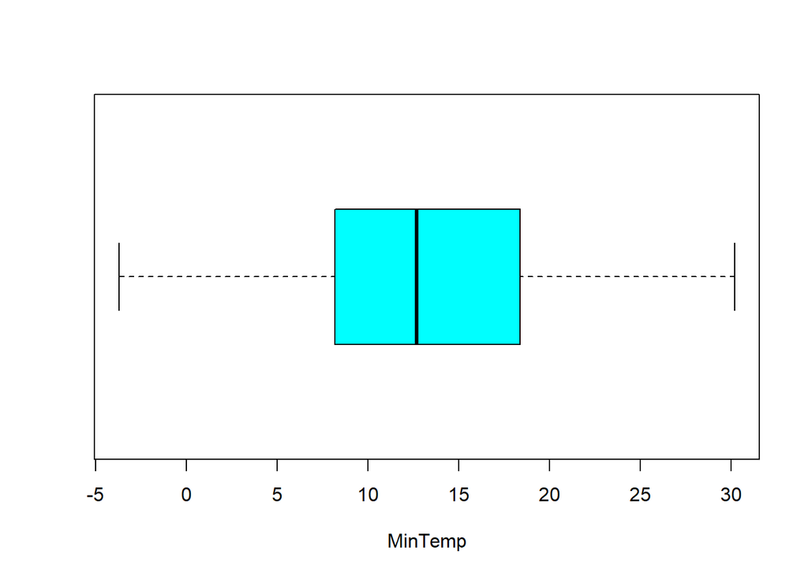

```r
boxplot(data$MinTemp, horizontal = TRUE, col = 'cyan', xlab = 'MinTemp')
```

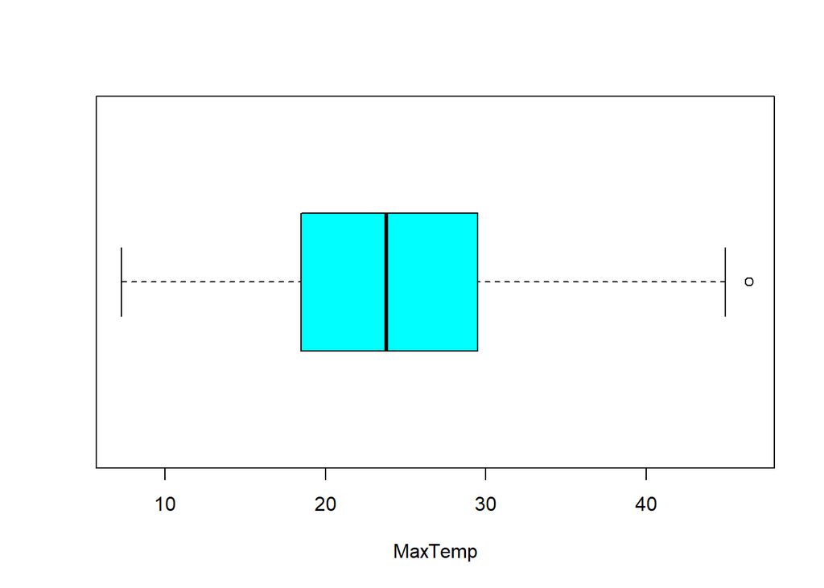

```r
boxplot(data$MaxTemp, horizontal = TRUE, col = 'cyan', xlab = 'MaxTemp')
```

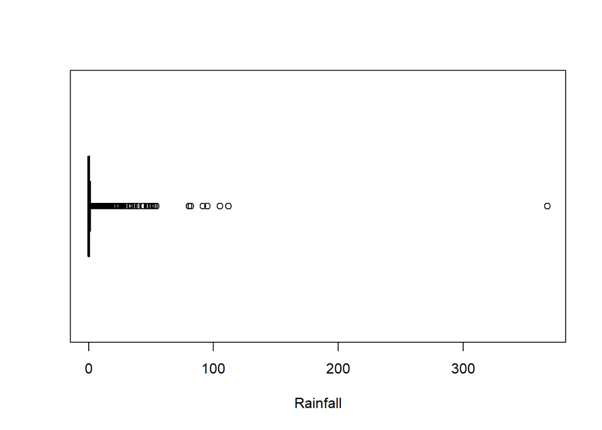

```r
boxplot(data$Rainfall, horizontal = TRUE, col = 'cyan', xlab = 'Rainfall')
```

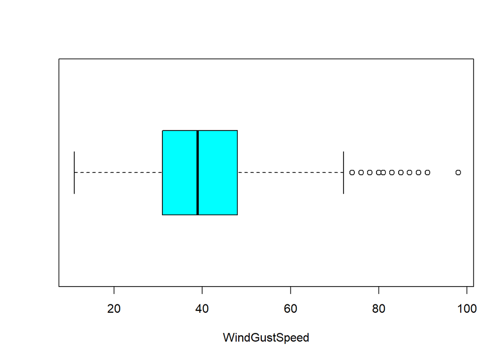

```r
boxplot(data$WindGustSpeed, horizontal = TRUE, col = 'cyan', xlab = 'WindGustSpeed')
```

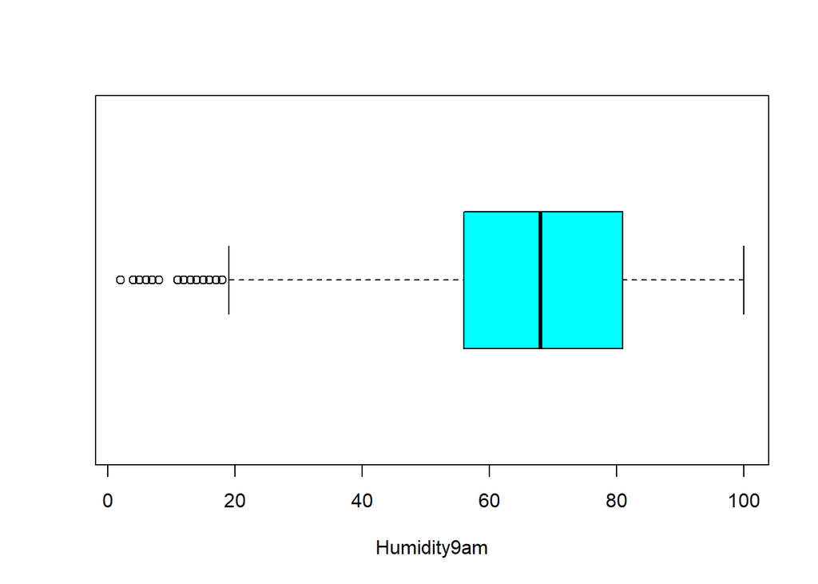

```r
boxplot(data$Humidity9am, horizontal = TRUE, col = 'cyan', xlab = 'Humidity9am')
```

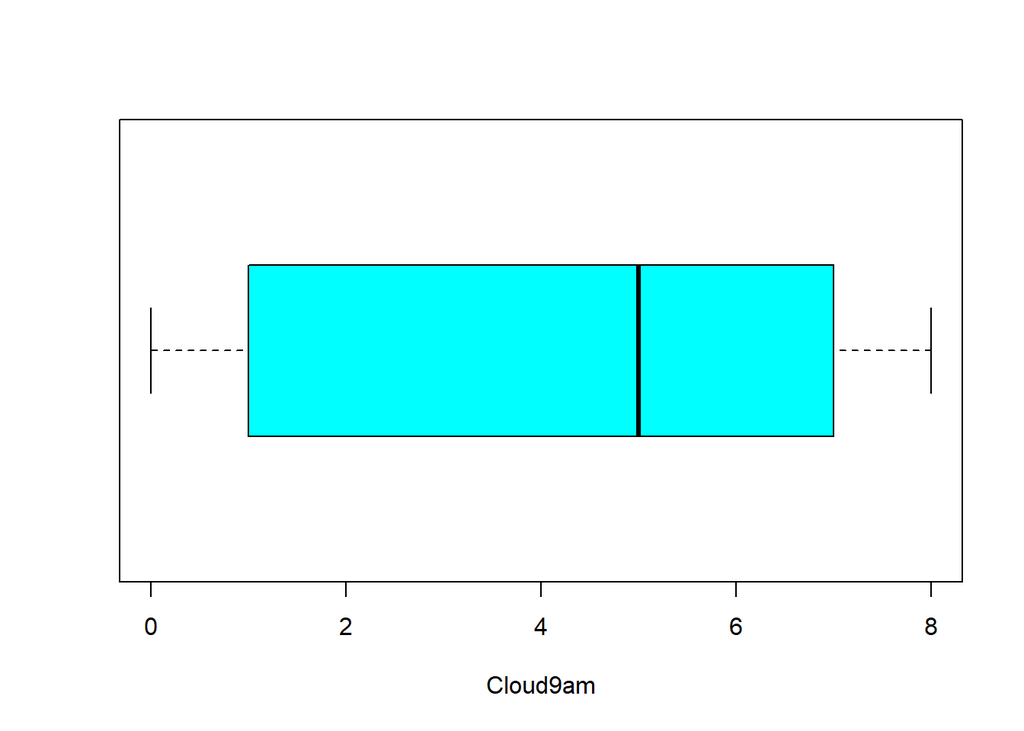

```r
boxplot(data$Cloud9am, horizontal = TRUE, col = 'cyan', xlab = 'Cloud9am')
```

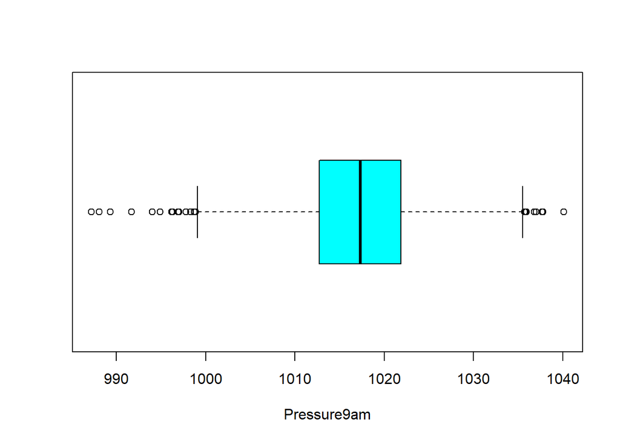

```r
boxplot(data$Pressure9am, horizontal = TRUE, col = 'cyan', xlab = 'Pressure9am')
```

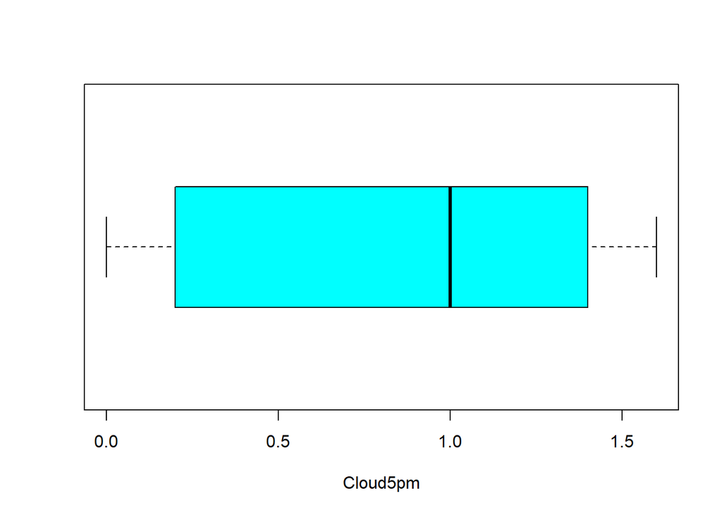

```r
boxplot(data$Cloud5pm, horizontal = TRUE, col = 'cyan', xlab = 'Cloud5pm')
```

Dalje, interesuje nas odnos između činjenice da li je padala kiša, i svih ostalih varijabli.

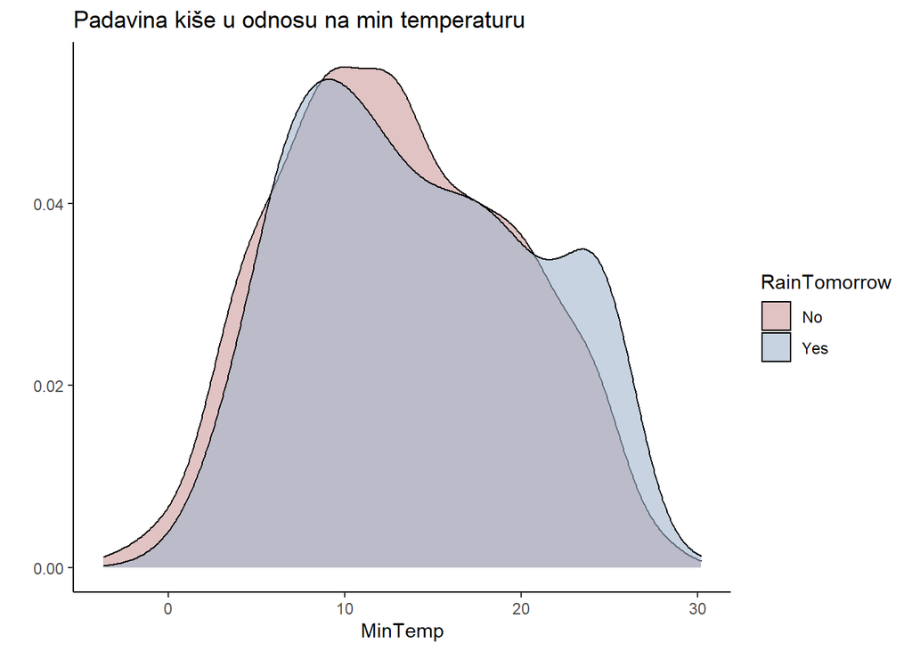

```r
library(ggplot2)
ggplot(data, aes(x = MinTemp, fill = RainTomorrow)) +
  geom_density(alpha = 0.6) +
  labs(x = "MinTemp", y = "") +
  ggtitle("Padavina kiše u odnosu na min temperaturu") +
  scale_fill_manual(values = c("rosybrown3","lightsteelblue3")) + theme_classic()
```

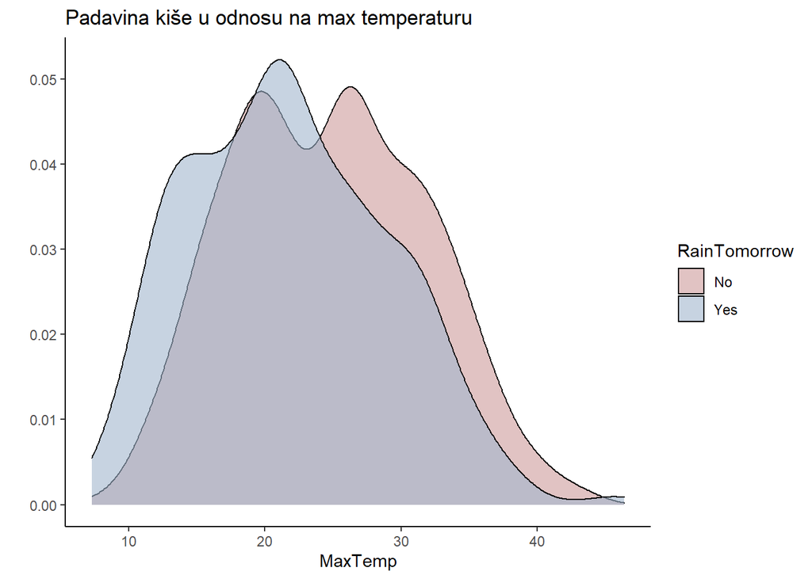

```r
ggplot(data, aes(x = MaxTemp, fill = RainTomorrow)) +
  geom_density(alpha = 0.6) +
  labs(x = "MaxTemp", y = "") +
  ggtitle("Padavina kiše u odnosu na max temperaturu") +
  scale_fill_manual(values = c("rosybrown3","lightsteelblue3")) + theme_classic()
```

[figure not shown]

```r
ggplot(data, aes(x = Rainfall, fill = RainTomorrow)) +
  geom_density(alpha = 0.6) +
  labs(x = "Rainfall", y = "") +
  ggtitle("Padavina kiše u odnosu na max temperaturu") +
  scale_fill_manual(values = c("rosybrown3","lightsteelblue3")) + theme_classic()
```

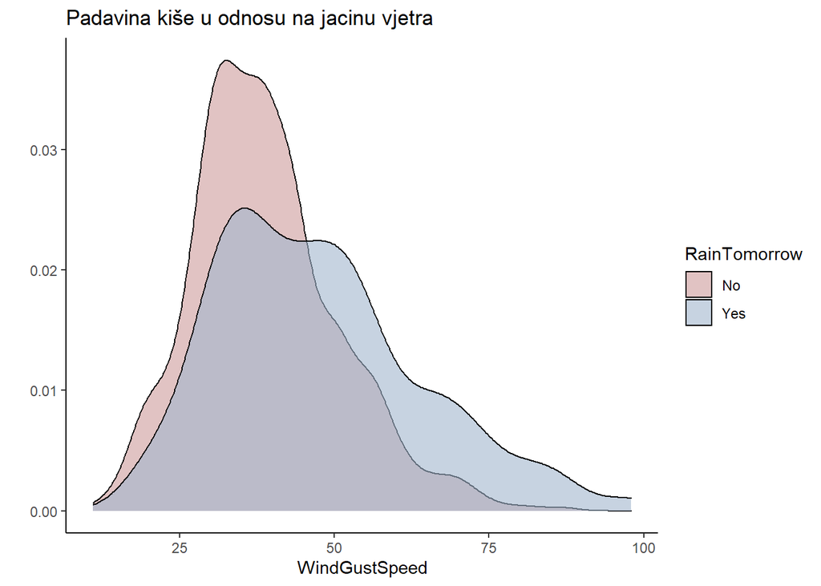

```r
ggplot(data, aes(x = WindGustSpeed, fill = RainTomorrow)) +
  geom_density(alpha = 0.6) +
  labs(x = "WindGustSpeed", y = "") +
  ggtitle("Padavina kiše u odnosu na jačinu vjetra") +
  scale_fill_manual(values = c("rosybrown3","lightsteelblue3")) + theme_classic()
```

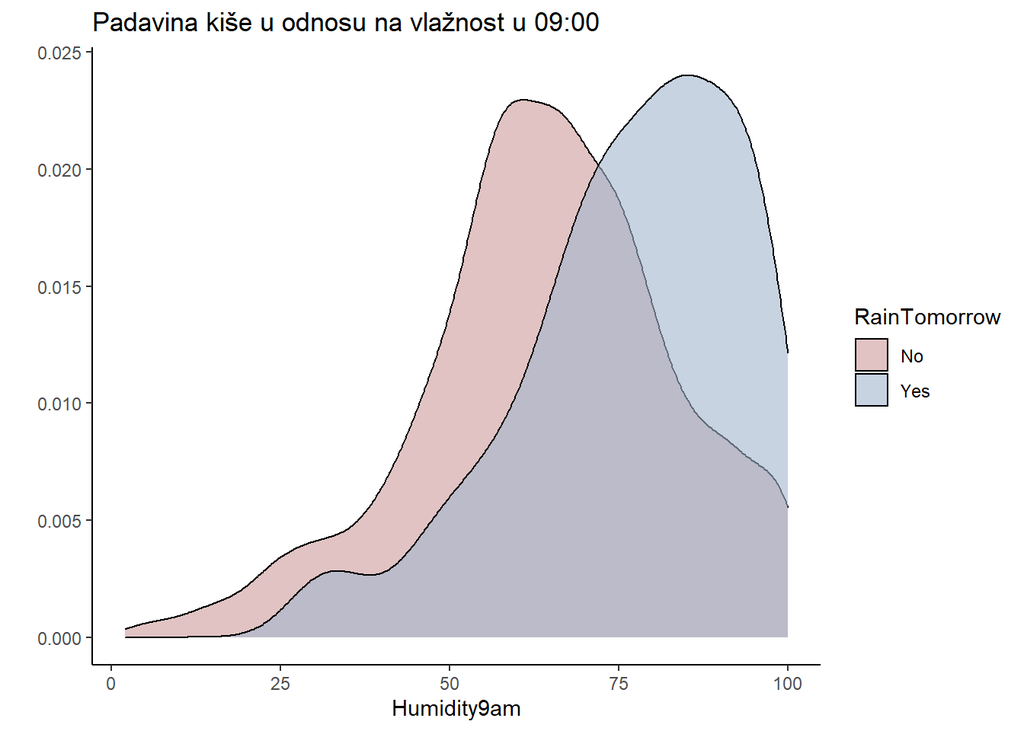

```r
ggplot(data, aes(x = Humidity9am, fill = RainTomorrow)) +
  geom_density(alpha = 0.6) +
  labs(x = "Humidity9am", y = "") +
  ggtitle("Padavina kiše u odnosu na vlažnost u 09:00") +
  scale_fill_manual(values = c("rosybrown3","lightsteelblue3")) + theme_classic()
```

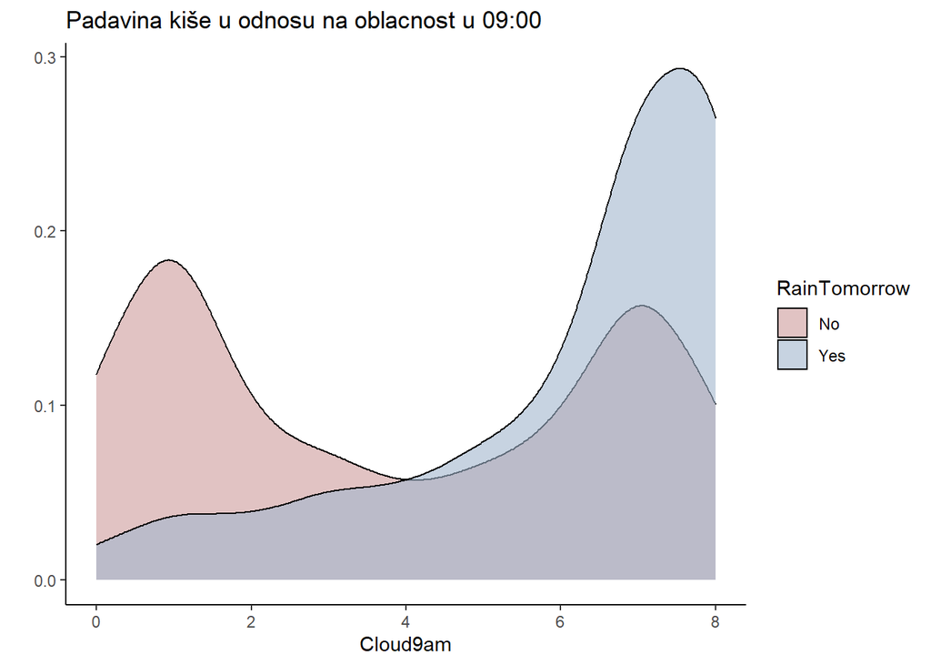

```r
ggplot(data, aes(x = Cloud9am, fill = RainTomorrow)) +
  geom_density(alpha = 0.6) +
  labs(x = "Cloud9am", y = "") +
  ggtitle("Padavina kiše u odnosu na oblačnost u 09:00") +
  scale_fill_manual(values = c("rosybrown3","lightsteelblue3")) + theme_classic()
```

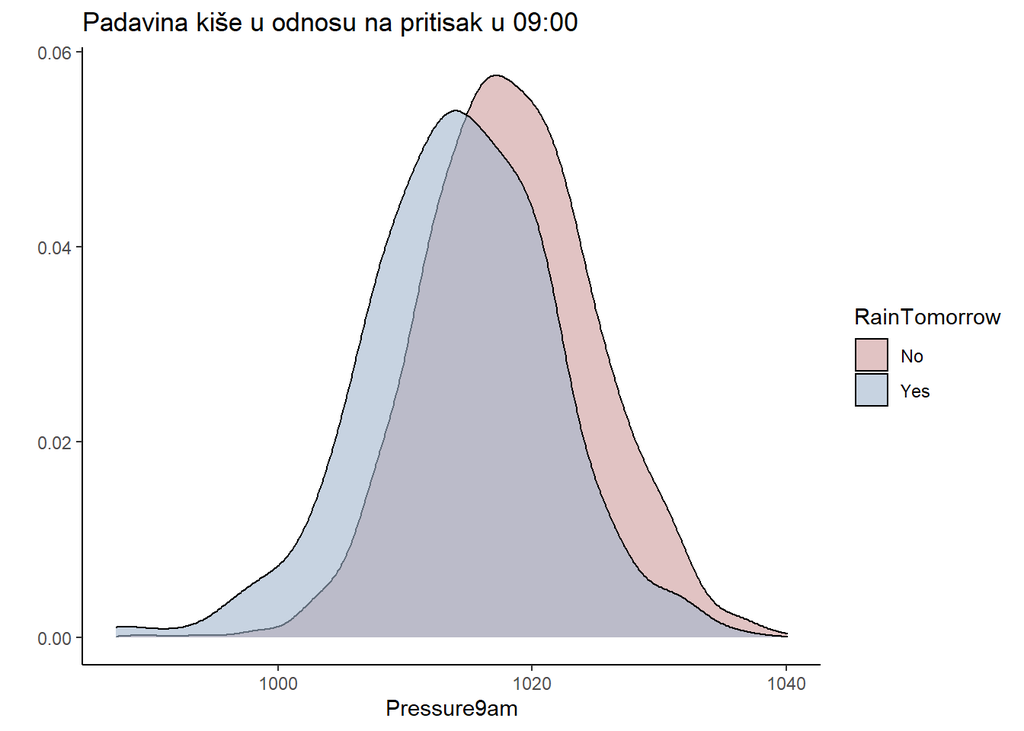

```r
ggplot(data, aes(x = Pressure9am, fill = RainTomorrow)) +
  geom_density(alpha = 0.6) +
  labs(x = "Pressure9am", y = "") +
  ggtitle("Padavina kiše u odnosu na pritisak u 09:00") +
  scale_fill_manual(values = c("rosybrown3","lightsteelblue3")) + theme_classic()
```

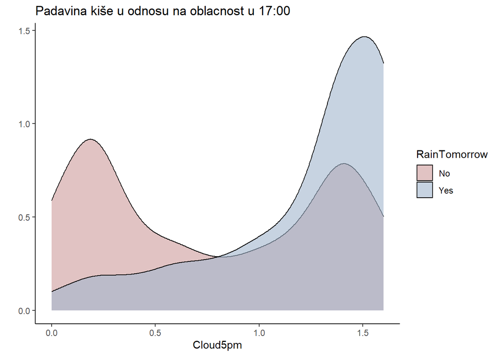

```r
ggplot(data, aes(x = Cloud5pm, fill = RainTomorrow)) +
  geom_density(alpha = 0.6) +
  labs(x = "Cloud5pm", y = "") +
  ggtitle("Padavina kiše u odnosu na oblačnost u 17:00") +
  scale_fill_manual(values = c("rosybrown3","lightsteelblue3")) + theme_classic()
```